# FEATURE ENGINEERING

# 9. SHAP

Nilai Shapley adalah konsep bidang teori permainan kooperatif, yang tujuannya adalah untuk mengukur kontribusi setiap pemain terhadap permainan. Metode untuk memperoleh nilai Shapley diusulkan oleh Lloyd Shapley [ 1 ] pada tahun 1953. Nilai Shapley muncul dari konteks di mana pemain “ n ” berpartisipasi secara kolektif untuk memperoleh hadiah “ p ” yang dimaksudkan untuk didistribusikan secara adil di masing-masing “ n ” ” pemain menurut kontribusi individu, kontribusi seperti itu adalah nilai Shapley.

SHAP adalah algoritm favorit untuk mendapatkan insight dari Machine Learning model kita. Jika algoritm diatas berbicara secara utuh bagaimana setiap fitur mempengaruhi performa model, SHAP lebih spesifik memperhitungkan bagaimana setiap spesifik fitur berpengaruh kepada setiap prediksi yang dilakukan

Shapley Additive Explanations (SHAP), adalah metode yang diperkenalkan oleh Lundberg dan Lee pada tahun 2017 [ 2 ] untuk interpretasi prediksi model ML melalui nilai Shapely. Ide utama SHAP adalah menghitung nilai Shapley untuk setiap fitur sampel yang akan diinterpretasikan, di mana setiap nilai Shapley mewakili dampak yang dihasilkan fitur terkait dalam prediksi.

[figure not shown]

```python
X = df[cols]
y = df['Churn']
```

```python
X_train, X_test, y_train, y_test = train_test_split(X, y, test_size=0.1, random_state=42, stratify=y)
X_train, X_val, y_train, y_val = train_test_split(X_train, y_train, test_size=2/9, random_state=42, stratify=y_train)
X_train.shape, X_val.shape, X_test.shape
```

```
((4921, 29), (1407, 29), (704, 29))
```

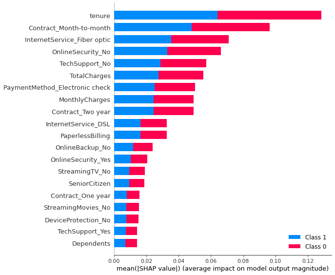

```python
import shap
classifier1 = RandomForestClassifier()
classifier1.fit(X_train,y_train)
explainer = shap.TreeExplainer(classifier1)
shap_val = explainer.shap_values(X_test.iloc[1])
shap.initjs()
shap.force_plot(explainer.expected_value[1], shap_val[1], X_test.iloc[1])
shap_val = explainer.shap_values(X_test)
shap.summary_plot(shap_val, X_test)
```

1. WRAPPER METHOD

Wrapper menggunakan strategi pencarian untuk mencari melalui ruang kemungkinan subset fitur dan mengevaluasi setiap subset berdasarkan kualitas kinerja pada algoritma ML. Hampir semua kombinasi strategi pencarian dan algoritma dapat digunakan sebagai pembungkus. Ditampilkan sebagai:

- Gunakan model ML untuk menilai subset fitur
- Melatih model baru di setiap subset
- Sangat mahal secara komputasi
- Biasanya memberikan subset berkinerja terbaik untuk algoritme ML yang diberikan, tetapi mungkin tidak untuk yang lain
- Membutuhkan kriteria penghentian yang ditentukan secara sewenang-wenang

```python
import pandas as pd
import numpy as np
from sklearn.model_selection import train_test_split
from mlxtend.feature_selection import SequentialFeatureSelector as SFS
from mlxtend.feature_selection import ExhaustiveFeatureSelector as EFS
from sklearn.ensemble import RandomForestRegressor, RandomForestClassifier
```

```python
from sklearn.datasets import load_breast_cancer
data = load_breast_cancer()
data = pd.DataFrame(np.c_[data['data'], data['target']], columns= np.append(data['feature_names'], ['target']))
```

```python
data
```

|  | mean radius | mean texture | mean perimeter | mean area | mean smoothness | mean compactness | mean concavity | mean concave points | mean symmetry | mean fractal dimension | ... | worst texture | worst perimeter | worst area | worst smoothness | worst compactness | worst concavity | worst concave points | worst symmetry | worst fractal dimension | target |
| --- | --- | --- | --- | --- | --- | --- | --- | --- | --- | --- | --- | --- | --- | --- | --- | --- | --- | --- | --- | --- | --- |
| 0 | 17.99 | 10.38 | 122.80 | 1001.0 | 0.11840 | 0.27760 | 0.30010 | 0.14710 | 0.2419 | 0.07871 | ... | 17.33 | 184.60 | 2019.0 | 0.16220 | 0.66560 | 0.7119 | 0.2654 | 0.4601 | 0.11890 | 0.0 |
| 1 | 20.57 | 17.77 | 132.90 | 1326.0 | 0.08474 | 0.07864 | 0.08690 | 0.07017 | 0.1812 | 0.05667 | ... | 23.41 | 158.80 | 1956.0 | 0.12380 | 0.18660 | 0.2416 | 0.1860 | 0.2750 | 0.08902 | 0.0 |
| 2 | 19.69 | 21.25 | 130.00 | 1203.0 | 0.10960 | 0.15990 | 0.19740 | 0.12790 | 0.2069 | 0.05999 | ... | 25.53 | 152.50 | 1709.0 | 0.14440 | 0.42450 | 0.4504 | 0.2430 | 0.3613 | 0.08758 | 0.0 |
| 3 | 11.42 | 20.38 | 77.58 | 386.1 | 0.14250 | 0.28390 | 0.24140 | 0.10520 | 0.2597 | 0.09744 | ... | 26.50 | 98.87 | 567.7 | 0.20980 | 0.86630 | 0.6869 | 0.2575 | 0.6638 | 0.17300 | 0.0 |
| 4 | 20.29 | 14.34 | 135.10 | 1297.0 | 0.10030 | 0.13280 | 0.19800 | 0.10430 | 0.1809 | 0.05883 | ... | 16.67 | 152.20 | 1575.0 | 0.13740 | 0.20500 | 0.4000 | 0.1625 | 0.2364 | 0.07678 | 0.0 |
| ... | ... | ... | ... | ... | ... | ... | ... | ... | ... | ... | ... | ... | ... | ... | ... | ... | ... | ... | ... | ... | ... |
| 564 | 21.56 | 22.39 | 142.00 | 1479.0 | 0.11100 | 0.11590 | 0.24390 | 0.13890 | 0.1726 | 0.05623 | ... | 26.40 | 166.10 | 2027.0 | 0.14100 | 0.21130 | 0.4107 | 0.2216 | 0.2060 | 0.07115 | 0.0 |
| 565 | 20.13 | 28.25 | 131.20 | 1261.0 | 0.09780 | 0.10340 | 0.14400 | 0.09791 | 0.1752 | 0.05533 | ... | 38.25 | 155.00 | 1731.0 | 0.11660 | 0.19220 | 0.3215 | 0.1628 | 0.2572 | 0.06637 | 0.0 |
| 566 | 16.60 | 28.08 | 108.30 | 858.1 | 0.08455 | 0.10230 | 0.09251 | 0.05302 | 0.1590 | 0.05648 | ... | 34.12 | 126.70 | 1124.0 | 0.11390 | 0.30940 | 0.3403 | 0.1418 | 0.2218 | 0.07820 | 0.0 |
| 567 | 20.60 | 29.33 | 140.10 | 1265.0 | 0.11780 | 0.27700 | 0.35140 | 0.15200 | 0.2397 | 0.07016 | ... | 39.42 | 184.60 | 1821.0 | 0.16500 | 0.86810 | 0.9387 | 0.2650 | 0.4087 | 0.12400 | 0.0 |
| 568 | 7.76 | 24.54 | 47.92 | 181.0 | 0.05263 | 0.04362 | 0.00000 | 0.00000 | 0.1587 | 0.05884 | ... | 30.37 | 59.16 | 268.6 | 0.08996 | 0.06444 | 0.0000 | 0.0000 | 0.2871 | 0.07039 | 1.0 |

569 rows × 31 columns

```python
X = data.drop(labels=['target'], axis=1)
y = data.target
X_train, X_test, y_train, y_test = train_test_split(X, y, test_size=0.2, random_state=0)
X_train.shape, X_test.shape
```

```
((455, 30), (114, 30))
```

## 1. Forward Selection

Step forward feature selection dimulai dengan mengevaluasi semua fitur satu per satu dan memilih salah satu yang menghasilkan algoritme berkinerja terbaik, menurut kriteria evaluasi yang telah ditentukan sebelumnya. Pada langkah kedua, ini mengevaluasi semua kemungkinan kombinasi fitur yang dipilih dan fitur kedua, dan memilih pasangan yang menghasilkan algoritme berkinerja terbaik berdasarkan kriteria yang telah ditetapkan sebelumnya.

Kriteria yang telah ditentukan sebelumnya dapat berupa roc_auc untuk klasifikasi dan r kuadrat untuk regresi misalnya.

Prosedur pemilihan ini mengevaluasi semua kemungkinan kombinasi fitur tunggal, ganda, tiga dan seterusnya. Oleh karena itu, ini cukup mahal secara komputasi, dan terkadang, jika ruang fitur besar, bahkan tidak layak

- Metode berulang yang dimulai dengan tidak memiliki fitur apapun dalam model.
- Pada setiap iterasinya, dilakukan penambahan fitur (dari fitur yang ada dilakukan selection) yang semakin meningkatkan performansi model
- Iterasi berhenti sampai penambahan fitur tidak lagi berdampak besar pada performansi

```python
# step forward feature selection
# select top 10 features based on the optimal roc_auc and RandomForest Classifier

sfs1 = SFS(RandomForestClassifier(n_jobs=-1,n_estimators=5),
           k_features=10,
           forward=True,
           floating=False,
           verbose=1,
           scoring='roc_auc',
           cv=3)

sfs1 = sfs1.fit(np.array(X_train), y_train)
```

[output not shown]

```python
selected_feat1= X_train.columns[list(sfs1.k_feature_idx_)]
selected_feat1
```

```
Index(['mean texture', 'mean area', 'mean concavity', 'radius error',
       'texture error', 'concavity error', 'worst perimeter', 'worst area',
       'worst smoothness', 'worst concavity'],
      dtype='object')
```

## 2. Backward Elimination

Pemilihan fitur Backward Elimination dimulai dengan memasang model menggunakan semua fitur. Kemudian menghapus satu fitur. Ini akan menghapus salah satu yang menghasilkan algoritma kinerja tertinggi (paling tidak signifikan secara statistik) untuk kriteria evaluasi tertentu. Pada langkah kedua, ia akan menghapus fitur kedua, fitur yang kembali menghasilkan algoritme berkinerja terbaik. Dan itu berlanjut, menghapus fitur demi fitur, hingga kriteria tertentu terpenuhi.

Kriteria yang telah ditentukan sebelumnya dapat berupa roc_auc untuk klasifikasi dan r kuadrat untuk regresi misalnya

- Metode ini dimulai dengan memasukkan semua fitur
- Pada setiap iterasinya dilakukan selection sehingga menghilangkan / menghapus fitur yang paling tidak signifikan berpengaruh pada performansi model.
- Iterasi berhenti sampai eliminasi fitur tidak lagi berdampak besar pada performansi

```python
# step backward feature selection
# select top 10 features based on the optimal roc_auc and RandomForest Classifier

sfs2 = SFS(RandomForestClassifier(n_jobs=-1,n_estimators=5),
           k_features=10,
           forward=False,
           floating=False,
           verbose=1,
           scoring='roc_auc',
           cv=3)

sfs2 = sfs1.fit(np.array(X_train.fillna(0)), y_train)
```

[output not shown]

```python
selected_feat2= X_train.columns[list(sfs2.k_feature_idx_)]
selected_feat2
```

```
Index(['mean texture', 'mean perimeter', 'mean compactness', 'perimeter error',
       'compactness error', 'concave points error', 'worst texture',
       'worst perimeter', 'worst concavity', 'worst symmetry'],
      dtype='object')
```

## 3. Exhaustive Feature Selection

Dalam Exhaustive Feature Selection, subset fitur terbaik dipilih, di atas semua subset fitur yang mungkin, dengan mengoptimalkan metrik kinerja yang ditentukan untuk algoritme pembelajaran mesin tertentu. Misalnya, jika pengklasifikasi adalah regresi logistik dan kumpulan data terdiri dari 4 fitur, algoritme akan mengevaluasi semua 15 kombinasi fitur sebagai berikut:

- Semua kemungkinan kombinasi dari 1 fitur
- Semua kemungkinan kombinasi dari 2 fitur
- Semua kemungkinan kombinasi dari 3 fitur
- Semua 4 fitur
- dan pilih salah satu yang menghasilkan kinerja terbaik (misalnya, akurasi klasifikasi) dari pengklasifikasi regresi logistik.

Pencarian lengkap ini sangat mahal secara komputasi. Dalam praktiknya untuk biaya komputasi ini, jarang digunakan

```python
efs1 = EFS(RandomForestClassifier(n_jobs=-1,n_estimators=5, random_state=0),
           min_features=1,
           max_features=6,
           scoring='roc_auc',
           print_progress=True,
           cv=2)

# in order to shorter search time for the demonstration
# we only try all possible 1,2,3,4,5,6
# feature combinations from a dataset of 10 features

efs1 = efs1.fit(np.array(X_train[X_train.columns[0:10]].fillna(0)), y_train)
```

```
Features: 847/847
```

```python
selected_feat3= X_train.columns[list(efs1.best_idx_)]
selected_feat3
```

```
Index(['mean radius', 'mean texture', 'mean area', 'mean smoothness',
       'mean concavity'],
      dtype='object')
```

1. EMBEDDED METHOD

Embedded Method menggabungkan keunggulan metode filter dan wrapped. Sebuah algoritma pembelajaran mengambil keuntungan dari proses pemilihan variabel sendiri dan melakukan seleksi fitur dan klasifikasi pada waktu yang sama. Embedded Method umum termasuk Lasso dan berbagai jenis algoritma berbasis pohon. Ini ditampilkan sebagai:

- Melakukan pemilihan fitur sebagai bagian dari proses pembuatan model
- Pertimbangkan interaksi antar fitur
- Lebih murah secara komputasi karena hanya melatih model sekali, dibandingkan dengan Wrappers
- Biasanya memberikan subset berkinerja terbaik untuk algoritme ML yang diberikan, tetapi mungkin tidak untuk yang lain
- Metode embedded menggabungkan efisiensi dari metode filter dan wrapper.
- Diimplementasikan oleh algoritma machine learning yang memiliki metode feature selection bawaan sendiri (builts-in).
- Jenis metode embedded yang paling umum adalah metode regularisasi, yaitu menambahkan fungsi kendala ke dalam algoritma untuk mengontrol kompleksitas model.
- Beberapa metode embedded antara lain: LASSO Regression dan Ridge Regression

```python
from sklearn.datasets import load_breast_cancer
from sklearn.linear_model import Lasso, LogisticRegression
from sklearn.preprocessing import RobustScaler
data = load_breast_cancer()
data = pd.DataFrame(np.c_[data['data'], data['target']], columns= np.append(data['feature_names'], ['target']))
```

```python
X_train, X_test, y_train, y_test = train_test_split(data.drop(labels=['target'], axis=1),
                                                    data.target, test_size=0.2,
                                                    random_state=0)
X_train.shape, X_test.shape
```

```
((455, 30), (114, 30))
```

# 1. RIDGE(L2) / LASSO (L1)

*RIDGE(L2)* = Berbeda dengan LASSO, metode ini dikenal sebagai L2 regularization, yaitu menambahkan fungsi penalti berupa kuadrat dari besarnya koefisien regresi

*LASSO(L1)* = Regularisasi dengan Lasso (L1) memiliki sifat yang mampu mengabsolutkan beberapa koefisien menjadi nol. Oleh karena itu, fitur tersebut dapat dihapus dari model

- Merupakan salah satu jenis regresi linier menggunakan teknik shrinkage (penyusutan).
- Shrinkage adalah saat nilai data menyusut menuju titik pusat, seperti mean (rataan).
- Dikenal sebagai L1 regularization, yaitu menambahkan fungsi penalti pada fungsi loss bernama least square error berupa nilai mutlak (absolute) dari besarnya koefisien regresi

```python
# linear models benefit from feature scaling

scaler = RobustScaler()
scaler.fit(X_train)
```

```
RobustScaler()
```

```python
# fit the LR model
sel_ = SelectFromModel(LogisticRegression(C=1, penalty='l2'))
sel_.fit(scaler.transform(X_train), y_train)
```

```
SelectFromModel(estimator=LogisticRegression(C=1))
```

```python
# make a list with the selected features
selected_feat = X_train.columns[(sel_.get_support())]

print('total features: {}'.format((X_train.shape[1])))
print('selected features: {}'.format(len(selected_feat)))
print('features with coefficients shrank to zero: {}'.format(
    np.sum(sel_.estimator_.coef_ == 0)))
```

```
total features: 30
selected features: 16
features with coefficients shrank to zero: 0
```

```python
# we can identify the removed features like this:
removed_feats = X_train.columns[(sel_.estimator_.coef_ == 0).ravel().tolist()]
removed_feats
```

```
Index([], dtype='object')
```

```python
# remove the features from the training and testing set

X_train_selected = sel_.transform(X_train.fillna(0))
X_test_selected = sel_.transform(X_test.fillna(0))

X_train_selected.shape, X_test_selected.shape
```

```
((455, 16), (114, 16))
```

# 2. Random Forest Importance

```python
from sklearn.ensemble import RandomForestClassifier, GradientBoostingClassifier #RandomForestRegressor
#from sklearn.feature_selection import SelectFromModel


def rf_importance(X_train,y_train,max_depth=10,class_weight=None,top_n=15,n_estimators=50,random_state=0):

    model = RandomForestClassifier(n_estimators=n_estimators,max_depth=max_depth,
                                    random_state=random_state,class_weight=class_weight,
                                    n_jobs=-1)
    model.fit(X_train, y_train)
    importances = model.feature_importances_
    indices = np.argsort(importances)[::-1]
    feat_labels = X_train.columns
    std = np.std([tree.feature_importances_ for tree in model.estimators_],
                 axis=0) #  inter-trees variability.
    print("Feature ranking:")
#    l1,l2,l3,l4 = [],[],[],[]
    for f in range(X_train.shape[1]):
        print("%d. feature no:%d feature name:%s (%f)" % (f + 1, indices[f], feat_labels[indices[f]], importances[indices[f]]))

    # plotting
    indices = indices[0:top_n]
    plt.figure()
    plt.title("Feature importances top %d" % top_n)
    plt.bar(range(top_n), importances[indices],
           color="r", yerr=std[indices], align="center")
    plt.xticks(range(top_n), indices)
    plt.xlim([-1,top_n])
    plt.show()

    return model
```

```
Feature ranking:
1. feature no:27 feature name:worst concave points (0.206316)
2. feature no:22 feature name:worst perimeter (0.147163)
3. feature no:7 feature name:mean concave points (0.100672)
4. feature no:20 feature name:worst radius (0.082449)
5. feature no:6 feature name:mean concavity (0.060420)
6. feature no:2 feature name:mean perimeter (0.048284)
7. feature no:23 feature name:worst area (0.046151)
8. feature no:3 feature name:mean area (0.038594)
9. feature no:13 feature name:area error (0.035627)
10. feature no:0 feature name:mean radius (0.030476)
11. feature no:10 feature name:radius error (0.028711)
12. feature no:26 feature name:worst concavity (0.028533)
13. feature no:12 feature name:perimeter error (0.019986)
14. feature no:21 feature name:worst texture (0.018623)
15. feature no:1 feature name:mean texture (0.013840)
16. feature no:25 feature name:worst compactness (0.013195)
17. feature no:29 feature name:worst fractal dimension (0.011840)
18. feature no:24 feature name:worst smoothness (0.008988)
19. feature no:28 feature name:worst symmetry (0.008973)
20. feature no:18 feature name:symmetry error (0.007378)
21. feature no:11 feature name:texture error (0.006736)
22. feature no:15 feature name:compactness error (0.005464)
23. feature no:19 feature name:fractal dimension error (0.005117)
24. feature no:16 feature name:concavity error (0.004957)
25. feature no:8 feature name:mean symmetry (0.004660)
26. feature no:4 feature name:mean smoothness (0.004614)
27. feature no:9 feature name:mean fractal dimension (0.003689)
28. feature no:17 feature name:concave points error (0.002993)
29. feature no:5 feature name:mean compactness (0.002844)
30. feature no:14 feature name:smoothness error (0.002706)
```

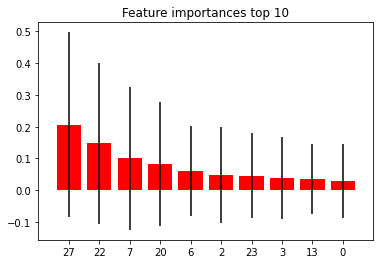

```python
model = rf_importance(X_train=X_train,y_train=y_train,
                             max_depth=10,top_n=10)
```

```python
# Memilih fitur yang sangat penting > threshold
from sklearn.feature_selection import SelectFromModel

# Hanya 5 fitur yang memiliki > 0.05
feature_selection = SelectFromModel(model,threshold=0.05,prefit=True)
selected_feat = X_train.columns[(feature_selection.get_support())]
selected_feat
```

```
Index(['mean concavity', 'mean concave points', 'worst radius',
       'worst perimeter', 'worst concave points'],
      dtype='object')
```

```python
# only 12 features have importance > 2 times median
feature_selection2 = SelectFromModel(model, threshold='2*median',prefit=True)
selected_feat2 = X_train.columns[(feature_selection2.get_support())]
selected_feat2
```

```
Index(['mean radius', 'mean perimeter', 'mean area', 'mean concavity',
       'mean concave points', 'radius error', 'area error', 'worst radius',
       'worst perimeter', 'worst area', 'worst concavity',
       'worst concave points'],
      dtype='object')
```

# 3. Gradient Boosted Trees Importance

```python
def gbt_importance(X_train,y_train,max_depth=10,top_n=15,n_estimators=50,random_state=0):

    model = GradientBoostingClassifier(n_estimators=n_estimators,max_depth=max_depth,
                                       random_state=random_state)
    model.fit(X_train, y_train)
    importances = model.feature_importances_
    indices = np.argsort(importances)[::-1]
    feat_labels = X_train.columns
    std = np.std([tree[0].feature_importances_ for tree in model.estimators_],
                 axis=0) #  inter-trees variability.
    print("Feature ranking:")
#    l1,l2,l3,l4 = [],[],[],[]
    for f in range(X_train.shape[1]):
        print("%d. feature no:%d feature name:%s (%f)" % (f + 1, indices[f], feat_labels[indices[f]], importances[indices[f]]))
#        l1.append(f+1)
#        l2.append(indices[f])
#        l3.append(feat_labels[indices[f]])
#        l4.append(importances[indices[f]])
#    feature_rank = pd.Dataframe(zip(l1,l2,l3,l4),columns=['id','indice','feature','importances'])
    # plotting
    indices = indices[0:top_n]
    plt.figure()
    plt.title("Feature importances top %d" % top_n)
    plt.bar(range(top_n), importances[indices],
           color="r", yerr=std[indices], align="center")
    plt.xticks(range(top_n), indices)
    plt.xlim([-1,top_n])
    plt.show()

    return model
```

```
Feature ranking:
1. feature no:27 feature name:worst concave points (0.693921)
2. feature no:23 feature name:worst area (0.130888)
3. feature no:4 feature name:mean smoothness (0.032633)
4. feature no:8 feature name:mean symmetry (0.019369)
5. feature no:22 feature name:worst perimeter (0.016477)
6. feature no:21 feature name:worst texture (0.011960)
7. feature no:2 feature name:mean perimeter (0.011832)
8. feature no:26 feature name:worst concavity (0.010018)
9. feature no:14 feature name:smoothness error (0.008797)
10. feature no:13 feature name:area error (0.007565)
11. feature no:10 feature name:radius error (0.007349)
12. feature no:16 feature name:concavity error (0.007268)
13. feature no:3 feature name:mean area (0.006811)
14. feature no:0 feature name:mean radius (0.005941)
15. feature no:1 feature name:mean texture (0.004734)
16. feature no:12 feature name:perimeter error (0.003513)
17. feature no:6 feature name:mean concavity (0.002965)
18. feature no:15 feature name:compactness error (0.002538)
19. feature no:17 feature name:concave points error (0.002413)
20. feature no:19 feature name:fractal dimension error (0.002232)
21. feature no:25 feature name:worst compactness (0.002222)
22. feature no:29 feature name:worst fractal dimension (0.002147)
23. feature no:18 feature name:symmetry error (0.001704)
24. feature no:11 feature name:texture error (0.001458)
25. feature no:7 feature name:mean concave points (0.001033)
26. feature no:9 feature name:mean fractal dimension (0.000927)
27. feature no:24 feature name:worst smoothness (0.000735)
28. feature no:20 feature name:worst radius (0.000286)
29. feature no:28 feature name:worst symmetry (0.000236)
30. feature no:5 feature name:mean compactness (0.000029)
```

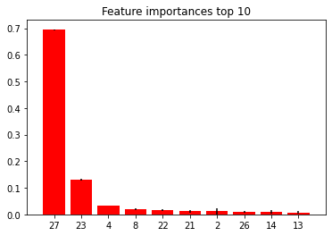

```python
model = gbt_importance(X_train=X_train,y_train=y_train,
                             max_depth=10,top_n=10)
```

```python
# select features whose importance > threshold

# only 8 features have importance > 0.01
feature_selection = SelectFromModel(model, threshold=0.01,prefit=True)
selected_feat = X_train.columns[(feature_selection.get_support())]
selected_feat
```

```
Index(['mean perimeter', 'mean smoothness', 'mean symmetry', 'worst texture',
       'worst perimeter', 'worst area', 'worst concavity',
       'worst concave points'],
      dtype='object')
```

# FEATURE TRANSFORMATION

Feature Transformation merupakan proses memodifikasi data tetapi tetap menyimpan informasi dari data tersebut. Proses modifikasi data dapat membantu algoritma Machine Learning lebih mudah dipahami serta memberikan hasil yang lebih baik

### 1. METODE RFM

RFM (Recency, Frequency, Monetary) adalah model segmentasi pasar berdasarkan perilaku pelanggan dengan cara

seberapa baru (recency), seberapa sering (frequency) dan berapa banyak (monetary) yang mereka beli.

- • RFM membantu membagi pelanggan ke dalam berbagai kategori atau klaster untuk mengidentifikasi pelanggan yang cenderung lebih menanggapi promosi dan juga untuk layanan personalisasi di masa mendatang

[figure not shown]

- *Best Recency score* = Berapa lama sejak transaksi terakhir dilakukan, semakin kecil nilainya maka semakin baik
- *Best Frequency score* = Jumlah keseluruhan dari banyaknya transaksi masing-masing customer.
- *Best Monetary score* = Jumlah keseluruhan dari nominal transaksi masing-masing customer

```python
data = pd.read_excel('https://github.com/fahmimnalfrzki/Additional-Materials/blob/main/online_retail_data.xlsx?raw=true').drop(columns='Unnamed: 0').sort_values('InvoiceDate',ascending=True).reset_index(drop=True)
data
```

|  | InvoiceNo | StockCode | Description | Quantity | InvoiceDate | UnitPrice | CustomerID | Country |
| --- | --- | --- | --- | --- | --- | --- | --- | --- |
| 0 | 536369 | 21756 | BATH BUILDING BLOCK WORD | 3 | 2010-12-01 08:35:00 | 5.95 | 13047.0 | United Kingdom |
| 1 | 536373 | 82482 | WOODEN PICTURE FRAME WHITE FINISH | 6 | 2010-12-01 09:02:00 | 2.10 | 17850.0 | United Kingdom |
| 2 | 536398 | 22752 | SET 7 BABUSHKA NESTING BOXES | 6 | 2010-12-01 10:52:00 | 8.50 | 13448.0 | United Kingdom |
| 3 | 536401 | 85150 | LADIES & GENTLEMEN METAL SIGN | 1 | 2010-12-01 11:21:00 | 2.55 | 15862.0 | United Kingdom |
| 4 | 536404 | 20727 | LUNCH BAG BLACK SKULL. | 10 | 2010-12-01 11:29:00 | 1.65 | 16218.0 | United Kingdom |
| ... | ... | ... | ... | ... | ... | ... | ... | ... |
| 9995 | 581501 | 22942 | CHRISTMAS LIGHTS 10 SANTAS | 12 | 2011-12-09 10:46:00 | 2.95 | 12985.0 | United Kingdom |
| 9996 | 581572 | 22627 | MINT KITCHEN SCALES | 4 | 2011-12-09 12:08:00 | 8.50 | 16705.0 | United Kingdom |
| 9997 | 581578 | 21507 | ELEPHANT BIRTHDAY CARD | 12 | 2011-12-09 12:16:00 | 0.42 | 12713.0 | Germany |
| 9998 | 581579 | 23353 | 6 GIFT TAGS VINTAGE CHRISTMAS | 12 | 2011-12-09 12:19:00 | 0.83 | 17581.0 | United Kingdom |
| 9999 | 581580 | 85049E | SCANDINAVIAN REDS RIBBONS | 2 | 2011-12-09 12:20:00 | 1.25 | 12748.0 | United Kingdom |

10000 rows × 8 columns

```python
data = data.dropna(subset=["CustomerID"])
```

```python
data = data[data['UnitPrice'] != 0]
```

```python
data['InvoiceDate']=pd.to_datetime(data['InvoiceDate'])
```

```python
data.drop_duplicates(inplace = True)
```

```python
data["TotalSold"] = data.Quantity * data.UnitPrice
data["Weekday"] = data.InvoiceDate.dt.day_name()
data["Hour"]=data.InvoiceDate.dt.hour
data["Month"]=data.InvoiceDate.dt.month
data.head()
```

|  | InvoiceNo | StockCode | Description | Quantity | InvoiceDate | UnitPrice | CustomerID | Country | TotalSold | Weekday | Hour | Month |
| --- | --- | --- | --- | --- | --- | --- | --- | --- | --- | --- | --- | --- |
| 0 | 536369 | 21756 | BATH BUILDING BLOCK WORD | 3 | 2010-12-01 08:35:00 | 5.95 | 13047.0 | United Kingdom | 17.85 | Wednesday | 8 | 12 |
| 1 | 536373 | 82482 | WOODEN PICTURE FRAME WHITE FINISH | 6 | 2010-12-01 09:02:00 | 2.10 | 17850.0 | United Kingdom | 12.60 | Wednesday | 9 | 12 |
| 2 | 536398 | 22752 | SET 7 BABUSHKA NESTING BOXES | 6 | 2010-12-01 10:52:00 | 8.50 | 13448.0 | United Kingdom | 51.00 | Wednesday | 10 | 12 |
| 3 | 536401 | 85150 | LADIES & GENTLEMEN METAL SIGN | 1 | 2010-12-01 11:21:00 | 2.55 | 15862.0 | United Kingdom | 2.55 | Wednesday | 11 | 12 |
| 4 | 536404 | 20727 | LUNCH BAG BLACK SKULL. | 10 | 2010-12-01 11:29:00 | 1.65 | 16218.0 | United Kingdom | 16.50 | Wednesday | 11 | 12 |

```python
data['StockCode']
```

[output not shown]

```python
data = data[data['StockCode']!= 'POST']
data = data[data['StockCode']!= 'M']
data = data[data['StockCode']!= 'BANK CHARGES']
data = data[data['StockCode']!= 'PADS']
data = data[data['StockCode']!= 'DOT']
```

```python
data["Recency"] = data.groupby(['CustomerID'])['InvoiceDate'].transform('max')
data["Days_Since_Last_Purchase"] = data["InvoiceDate"].max() - data["Recency"]
```

```python
data = (data.assign(Frequency = lambda x:x.groupby('CustomerID')['InvoiceNo'].transform('count')))
data = (data.assign(Monetary_Value = lambda x:x.groupby('CustomerID')['TotalSold'].transform('sum')))
```

```python
data_RFM = data[["CustomerID", "Recency","Days_Since_Last_Purchase", "Frequency", "Monetary_Value"]]
```

```python
data_RFM["Days_Since_Last_Purchase"] = data_RFM["Days_Since_Last_Purchase"].dt.days
```

```python
data_RFM.head()
```

|  | CustomerID | Recency | Days_Since_Last_Purchase | Frequency | Monetary_Value |
| --- | --- | --- | --- | --- | --- |
| 0 | 13047.0 | 2011-06-19 13:56:00 | 172 | 4 | 84.75 |
| 1 | 17850.0 | 2010-12-02 14:04:00 | 371 | 7 | 106.88 |
| 2 | 13448.0 | 2011-11-23 12:33:00 | 15 | 4 | 95.70 |
| 3 | 15862.0 | 2011-12-01 13:28:00 | 7 | 4 | 5.52 |
| 4 | 16218.0 | 2010-12-01 11:29:00 | 373 | 1 | 16.50 |

```python
data_RFM.drop_duplicates(inplace = True)
```

```python
quantiles = data_RFM.quantile(q=[0.25,0.50,0.75])
quantiles = quantiles.to_dict()
segmented_RFM = data_RFM.copy()
```

```python
def RScore(x,p,d):
    if x <= d[p][0.25]:
        return 1
    elif x <= d[p][0.50]:
        return 2
    elif x <= d[p][0.75]:
        return 3
    else:
        return 4

def FMScore(x,p,d):
    if x <= d[p][0.25]:
        return 4
    elif x <= d[p][0.50]:
        return 3
    elif x <= d[p][0.75]:
        return 2
    else:
        return 1
```

```python
segmented_RFM['R_quartile'] = segmented_RFM['Days_Since_Last_Purchase'].apply(RScore, args=('Days_Since_Last_Purchase',quantiles))
segmented_RFM['F_quartile'] = segmented_RFM['Frequency'].apply(FMScore, args=('Frequency',quantiles))
segmented_RFM['M_quartile'] = segmented_RFM['Monetary_Value'].apply(FMScore, args=('Monetary_Value',quantiles))
segmented_RFM.head()
```

|  | CustomerID | Recency | Days_Since_Last_Purchase | Frequency | Monetary_Value | R_quartile | F_quartile | M_quartile |
| --- | --- | --- | --- | --- | --- | --- | --- | --- |
| 0 | 13047.0 | 2011-06-19 13:56:00 | 172 | 4 | 84.75 | 3 | 1 | 1 |
| 1 | 17850.0 | 2010-12-02 14:04:00 | 371 | 7 | 106.88 | 4 | 1 | 1 |
| 2 | 13448.0 | 2011-11-23 12:33:00 | 15 | 4 | 95.70 | 1 | 1 | 1 |
| 3 | 15862.0 | 2011-12-01 13:28:00 | 7 | 4 | 5.52 | 1 | 1 | 4 |
| 4 | 16218.0 | 2010-12-01 11:29:00 | 373 | 1 | 16.50 | 4 | 4 | 3 |

```python
segmented_RFM['RFM_Segment'] = segmented_RFM.R_quartile.map(str)+segmented_RFM.F_quartile.map(str)+segmented_RFM.M_quartile.map(str)
segmented_RFM.head()
```

|  | CustomerID | Recency | Days_Since_Last_Purchase | Frequency | Monetary_Value | R_quartile | F_quartile | M_quartile | RFM_Segment |
| --- | --- | --- | --- | --- | --- | --- | --- | --- | --- |
| 0 | 13047.0 | 2011-06-19 13:56:00 | 172 | 4 | 84.75 | 3 | 1 | 1 | 311 |
| 1 | 17850.0 | 2010-12-02 14:04:00 | 371 | 7 | 106.88 | 4 | 1 | 1 | 411 |
| 2 | 13448.0 | 2011-11-23 12:33:00 | 15 | 4 | 95.70 | 1 | 1 | 1 | 111 |
| 3 | 15862.0 | 2011-12-01 13:28:00 | 7 | 4 | 5.52 | 1 | 1 | 4 | 114 |
| 4 | 16218.0 | 2010-12-01 11:29:00 | 373 | 1 | 16.50 | 4 | 4 | 3 | 443 |

```python
segmented_RFM['RFM_Score'] = segmented_RFM[['R_quartile','F_quartile','M_quartile']].sum(axis=1)
segmented_RFM.head()
```

|  | CustomerID | Recency | Days_Since_Last_Purchase | Frequency | Monetary_Value | R_quartile | F_quartile | M_quartile | RFM_Segment | RFM_Score |
| --- | --- | --- | --- | --- | --- | --- | --- | --- | --- | --- |
| 0 | 13047.0 | 2011-06-19 13:56:00 | 172 | 4 | 84.75 | 3 | 1 | 1 | 311 | 5 |
| 1 | 17850.0 | 2010-12-02 14:04:00 | 371 | 7 | 106.88 | 4 | 1 | 1 | 411 | 6 |
| 2 | 13448.0 | 2011-11-23 12:33:00 | 15 | 4 | 95.70 | 1 | 1 | 1 | 111 | 3 |
| 3 | 15862.0 | 2011-12-01 13:28:00 | 7 | 4 | 5.52 | 1 | 1 | 4 | 114 | 6 |
| 4 | 16218.0 | 2010-12-01 11:29:00 | 373 | 1 | 16.50 | 4 | 4 | 3 | 443 | 11 |

```python
segmented_RFM['RFM_Score'].unique()
```

```
array([ 5,  6,  3, 11,  9,  4, 10,  8, 12,  7], dtype=int64)
```

```python
segmented_RFM.groupby('RFM_Score').agg({
    'Days_Since_Last_Purchase': 'mean',
    'Frequency': 'mean',
    'Monetary_Value': ['mean', 'count'] }).round(1)
```

| RFM_Score | Days_Since_Last_Purchase mean | Frequency mean | Monetary_Value mean | Monetary_Value count |
| --- | --- | --- | --- | --- |
| 3 | 10.9 | 12.3 | 276.2 | 184 |
| 4 | 30.3 | 6.3 | 120.6 | 184 |
| 5 | 57.7 | 4.7 | 104.9 | 183 |
| 6 | 62.3 | 3.2 | 58.9 | 198 |
| 7 | 72.2 | 2.4 | 46.3 | 252 |
| 8 | 89.8 | 1.8 | 45.0 | 302 |
| 9 | 121.0 | 1.5 | 32.9 | 355 |
| 10 | 140.7 | 1.3 | 15.3 | 321 |
| 11 | 216.7 | 1.1 | 11.9 | 305 |
| 12 | 278.7 | 1.0 | 4.7 | 139 |

### 2. METODE PCA

Sesuai dengan namanya, PCA membentuk variabel baru bernama PC. Variabel PC ini akan menggantikan variabel X pada analisis selanjutnya. Persamaan analisis komponen utama yaitu

#### RUMUS

[figure not shown]

Persamaan di atas menunjukkan bahwa variabel baru yaitu PC adalah kombinasi linier dari variabel awal. PC1 adalah variabel yang menjelaskan keragaman paling besar diikuti oleh PC2, PC3,… dst. PCA menjamin bahwa PC1, PC2, PC3,… dst saling bebas. Pada regresi ridge, variabel PC1, PC2, PC3,… dst inilah yang akan menggantikan variabel awal.

Terdapat dua jenis matrix yang digunakan dalam PCA yaitu matrix korelasi dan matrik covariance. Jika satuan dari semua variabel sama, maka sebaiknya menggunakan matriks covariance. Jika antar variabel mempunyai satuan yang berbeda-beda, maka gunakanlah matriks korelasi (menghilangkan efek satuan). Pemilihan matrix masukan tersebut akan menentukan nilai dari konstanta a12,13,…dst yang nantinya akan menghasilkan nilai eigen.

*Nilai eigen* menunjukkan jumlah varian yang mampu dijelaskan oleh suatu komponen utama. Nilai eigen ini nantinya juga akan berperan dalam pemilihan banyaknya dimensi.

Tahapan PCA Berikut merupakan tahapan-tahapan dalam melakukan PCA

#### *a. Standarisasi data*

Standarisasi diperlukan karena efek satuan (misal satuan panjang seperti cm, km, dm) akan mempengaruhi matriks covariance.

#### *b. Menghitung matrik covariance/korelasi*

Matriks varian kovariance berfungsi sebagai nilai masukan untuk mendapatkan nilai eigen dan vector eigen.

#### *c. Menghitung nilai eigen*

Eigen value menyatakan seberapa besar keragaman yang mampu dijelaskan oleh suatu Variabel PC.

#### *d. Menghitung PC*

Karena nilai eigen dan vektor eigen sudah diketahui, maka nilai setiap PC bisa dihitung.

#### *e. Reduksi Dimensi*

Tidak semua variabel PC akan dipilih, hanya PC yang mempunyai nilai eigen > 1 yang akan dipilih.

```python
df=pd.read_csv('WA_Fn-UseC_-Telco-Customer-Churn.csv', na_values=[' '])
df["TotalCharges"] = pd.to_numeric(df["TotalCharges"],errors="coerce")
df.dropna(how="any",inplace=True)
```

```python
df.info()
```

```
<class 'pandas.core.frame.DataFrame'>
Int64Index: 7032 entries, 0 to 7042
Data columns (total 21 columns):
 #   Column            Non-Null Count  Dtype
---  ------            --------------  -----
 0   customerID        7032 non-null   object
 1   gender            7032 non-null   object
 2   SeniorCitizen     7032 non-null   int64
 3   Partner           7032 non-null   object
 4   Dependents        7032 non-null   object
 5   tenure            7032 non-null   int64
 6   PhoneService      7032 non-null   object
 7   MultipleLines     7032 non-null   object
 8   InternetService   7032 non-null   object
 9   OnlineSecurity    7032 non-null   object
 10  OnlineBackup      7032 non-null   object
 11  DeviceProtection  7032 non-null   object
 12  TechSupport       7032 non-null   object
 13  StreamingTV       7032 non-null   object
 14  StreamingMovies   7032 non-null   object
 15  Contract          7032 non-null   object
 16  PaperlessBilling  7032 non-null   object
 17  PaymentMethod     7032 non-null   object
 18  MonthlyCharges    7032 non-null   float64
 19  TotalCharges      7032 non-null   float64
 20  Churn             7032 non-null   object
dtypes: float64(2), int64(2), object(17)
memory usage: 1.2+ MB
```

```python
num_cols = list(df.select_dtypes(["float64", "int64"]).columns)
num_cols
```

```
['SeniorCitizen', 'tenure', 'MonthlyCharges', 'TotalCharges']
```

```python
df_numeric = df[num_cols]
```

```python
df_numeric
```

|  | SeniorCitizen | tenure | MonthlyCharges | TotalCharges |
| --- | --- | --- | --- | --- |
| 0 | 0 | 1 | 29.85 | 29.85 |
| 1 | 0 | 34 | 56.95 | 1889.50 |
| 2 | 0 | 2 | 53.85 | 108.15 |
| 3 | 0 | 45 | 42.30 | 1840.75 |
| 4 | 0 | 2 | 70.70 | 151.65 |
| ... | ... | ... | ... | ... |
| 7038 | 0 | 24 | 84.80 | 1990.50 |
| 7039 | 0 | 72 | 103.20 | 7362.90 |
| 7040 | 0 | 11 | 29.60 | 346.45 |
| 7041 | 1 | 4 | 74.40 | 306.60 |
| 7042 | 0 | 66 | 105.65 | 6844.50 |

7032 rows × 4 columns

```python
from sklearn.preprocessing import StandardScaler
scaler=StandardScaler()
df_PCA_scalled=scaler.fit_transform(df_numeric)
```

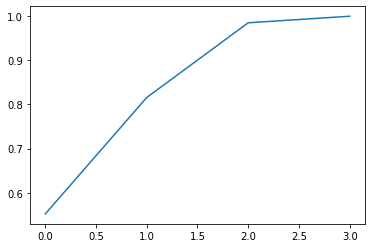

```python
from sklearn.decomposition import PCA
pca=PCA(whiten=True)
pca.fit(df_PCA_scalled)
cumsum = np.cumsum(pca.explained_variance_ratio_)

plt.figure()
plt.plot(cumsum)
```

```python
cumsum
```

```
array([0.55204257, 0.81588427, 0.98519224, 1.        ])
```

```python
np.sum(pca.explained_variance_ratio_)
```

```
1.0
```

```python
pca_60d=PCA(n_components=2).fit(df_PCA_scalled)
num_reduced= pca_60d.transform(df_PCA_scalled)
num_reduced
```

```
array([[-1.99747885, -0.1493272 ],
       [-0.27437992, -0.46390274],
       [-1.55864937,  0.07615256],
       ...,
       [-1.68556544, -0.31650907],
       [-0.70565266,  2.60818558],
       [ 2.675781  , -0.72429845]])
```

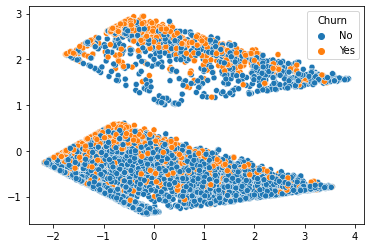

```python
sns.scatterplot(x=num_reduced[:,0],y=num_reduced[:,1], hue=df['Churn'])
```

```python
df_PCA_final=pd.DataFrame(data=num_reduced,columns=["num1","num2"])
df_PCA_final.head()
```

|  | num1 | num2 |
| --- | --- | --- |
| 0 | -1.997479 | -0.149327 |
| 1 | -0.274380 | -0.463903 |
| 2 | -1.558649 | 0.076153 |
| 3 | -0.281920 | -0.771179 |
| 4 | -1.269631 | 0.245389 |

```python
df_final = pd.merge(df, df_PCA_final, left_index=True, right_index=True)
```

```python
df_final.info()
```

```
<class 'pandas.core.frame.DataFrame'>
Int64Index: 7021 entries, 0 to 7031
Data columns (total 23 columns):
 #   Column            Non-Null Count  Dtype
---  ------            --------------  -----
 0   customerID        7021 non-null   object
 1   gender            7021 non-null   object
 2   SeniorCitizen     7021 non-null   int64
 3   Partner           7021 non-null   object
 4   Dependents        7021 non-null   object
 5   tenure            7021 non-null   int64
 6   PhoneService      7021 non-null   object
 7   MultipleLines     7021 non-null   object
 8   InternetService   7021 non-null   object
 9   OnlineSecurity    7021 non-null   object
 10  OnlineBackup      7021 non-null   object
 11  DeviceProtection  7021 non-null   object
 12  TechSupport       7021 non-null   object
 13  StreamingTV       7021 non-null   object
 14  StreamingMovies   7021 non-null   object
 15  Contract          7021 non-null   object
 16  PaperlessBilling  7021 non-null   object
 17  PaymentMethod     7021 non-null   object
 18  MonthlyCharges    7021 non-null   float64
 19  TotalCharges      7021 non-null   float64
 20  Churn             7021 non-null   object
 21  num1              7021 non-null   float64
 22  num2              7021 non-null   float64
dtypes: float64(4), int64(2), object(17)
memory usage: 1.3+ MB
```

### 3. METODE TRANSFORMASI

```python
import pylab
df=pd.read_csv('train.csv',nrows=10000)
X=df.drop(labels=['TARGET'], axis=1)
y=df['TARGET']
X_train, X_test, y_train, y_test = train_test_split(X, y, test_size=0.3, random_state=0)
X_train.shape, X_test.shape
```

```
((7000, 370), (3000, 370))
```

```python
def diagnostic_plots(df, variable):
    # function to plot a histogram and a Q-Q plot
    # side by side, for a certain variable

    plt.figure(figsize=(15,6))
    plt.subplot(1, 2, 1)
    df[variable].hist()

    plt.subplot(1, 2, 2)
    stats.probplot(df[variable], dist="norm", plot=pylab)

    plt.show()
```

```python
df
```

|  | ID | var3 | var15 | imp_ent_var16_ult1 | imp_op_var39_comer_ult1 | imp_op_var39_comer_ult3 | imp_op_var40_comer_ult1 | imp_op_var40_comer_ult3 | imp_op_var40_efect_ult1 | imp_op_var40_efect_ult3 | ... | saldo_medio_var33_hace2 | saldo_medio_var33_hace3 | saldo_medio_var33_ult1 | saldo_medio_var33_ult3 | saldo_medio_var44_hace2 | saldo_medio_var44_hace3 | saldo_medio_var44_ult1 | saldo_medio_var44_ult3 | var38 | TARGET |
| --- | --- | --- | --- | --- | --- | --- | --- | --- | --- | --- | --- | --- | --- | --- | --- | --- | --- | --- | --- | --- | --- |
| 0 | 1 | 2 | 23 | 0.0 | 0.00 | 0.00 | 0.0 | 0.0 | 0 | 0 | ... | 0.0 | 0.0 | 0.0 | 0.0 | 0.0 | 0.0 | 0.0 | 0.0 | 39205.170000 | 0 |
| 1 | 3 | 2 | 34 | 0.0 | 0.00 | 0.00 | 0.0 | 0.0 | 0 | 0 | ... | 0.0 | 0.0 | 0.0 | 0.0 | 0.0 | 0.0 | 0.0 | 0.0 | 49278.030000 | 0 |
| 2 | 4 | 2 | 23 | 0.0 | 0.00 | 0.00 | 0.0 | 0.0 | 0 | 0 | ... | 0.0 | 0.0 | 0.0 | 0.0 | 0.0 | 0.0 | 0.0 | 0.0 | 67333.770000 | 0 |
| 3 | 8 | 2 | 37 | 0.0 | 195.00 | 195.00 | 0.0 | 0.0 | 0 | 0 | ... | 0.0 | 0.0 | 0.0 | 0.0 | 0.0 | 0.0 | 0.0 | 0.0 | 64007.970000 | 0 |
| 4 | 10 | 2 | 39 | 0.0 | 0.00 | 0.00 | 0.0 | 0.0 | 0 | 0 | ... | 0.0 | 0.0 | 0.0 | 0.0 | 0.0 | 0.0 | 0.0 | 0.0 | 117310.979016 | 0 |
| ... | ... | ... | ... | ... | ... | ... | ... | ... | ... | ... | ... | ... | ... | ... | ... | ... | ... | ... | ... | ... | ... |
| 9995 | 20069 | 2 | 52 | 150.0 | 0.00 | 0.00 | 0.0 | 0.0 | 0 | 0 | ... | 0.0 | 0.0 | 0.0 | 0.0 | 0.0 | 0.0 | 0.0 | 0.0 | 27745.740000 | 1 |
| 9996 | 20070 | 2 | 23 | 90.0 | 51.06 | 51.06 | 0.0 | 0.0 | 0 | 0 | ... | 0.0 | 0.0 | 0.0 | 0.0 | 0.0 | 0.0 | 0.0 | 0.0 | 120468.090000 | 0 |
| 9997 | 20071 | 2 | 37 | 0.0 | 0.00 | 0.00 | 0.0 | 0.0 | 0 | 0 | ... | 0.0 | 0.0 | 0.0 | 0.0 | 0.0 | 0.0 | 0.0 | 0.0 | 98462.880000 | 0 |
| 9998 | 20072 | 2 | 24 | 0.0 | 0.00 | 0.00 | 0.0 | 0.0 | 0 | 0 | ... | 0.0 | 0.0 | 0.0 | 0.0 | 0.0 | 0.0 | 0.0 | 0.0 | 102070.770000 | 0 |
| 9999 | 20074 | 2 | 40 | 585.0 | 0.00 | 0.00 | 0.0 | 0.0 | 0 | 0 | ... | 0.0 | 0.0 | 0.0 | 0.0 | 0.0 | 0.0 | 0.0 | 0.0 | 55804.410000 | 0 |

10000 rows × 371 columns

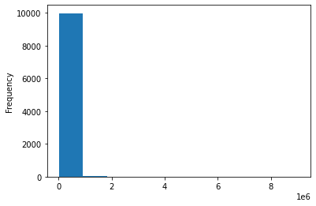

```python
df['var38'].plot(kind='hist')
```

#### 1. Logarithmic transformation

Logarithmic transformation berguna bila diterapkan pada distribusi skew karena cenderung memperluas nilai yang berada dalam kisaran besaran yang lebih rendah dan cenderung memampatkan atau mengurangi nilai yang berada dalam kisaran besaran yang lebih tinggi, yang membantu membuat distribusi miring menjadi normal -suka mungkin. Transformasi akar kuadrat melakukan hal serupa dalam pengertian ini.

```
Variable var38 Q-Q plot
```

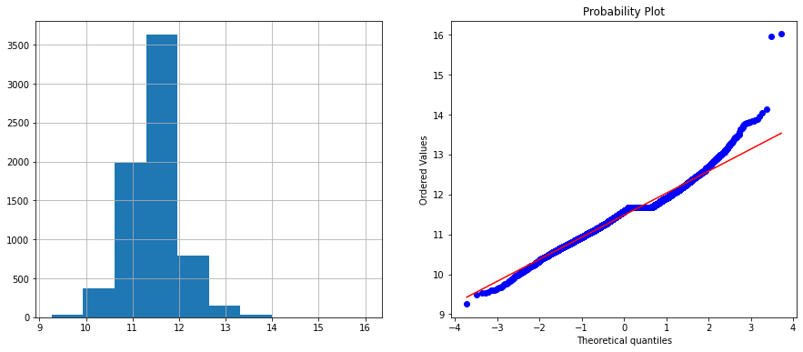

```
         ID  var3  var15  imp_ent_var16_ult1  imp_op_var39_comer_ult1  \
7681  15431     2     42               840.0                  4477.02
9031  18181     2     31                 0.0                    52.32
3691   7411     2     51                 0.0                     0.00
202     407     2     36                 0.0                     0.00
5625  11280     2     23                 0.0                     0.00
298     598     2     40                 0.0                     0.00

      imp_op_var39_comer_ult3  imp_op_var40_comer_ult1  \
7681                  4989.54                      0.0
9031                    52.32                      0.0
3691                     0.00                      0.0
202                      0.00                      0.0
5625                     0.00                      0.0
298                      0.00                      0.0
```

[output cut: 42 more lines]

```python
def log_transform(data,cols=[]):
    """
    Logarithmic transformation
    """

    data_copy = data.copy(deep=True)
    for i in cols:
        data_copy[i+'_log'] = np.log(data_copy[i]+1)
        print('Variable ' + i +' Q-Q plot')
        diagnostic_plots(data_copy,str(i+'_log'))
    return data_copy

# add the new created feature
X_train_copy = X_train.copy(deep=True)
X_train_copy = log_transform(data=X_train,cols=['var38'])
print(X_train_copy.head(6))
```

#### 2. Reciprocal transformation

```
Variable var38 Q-Q plot
```

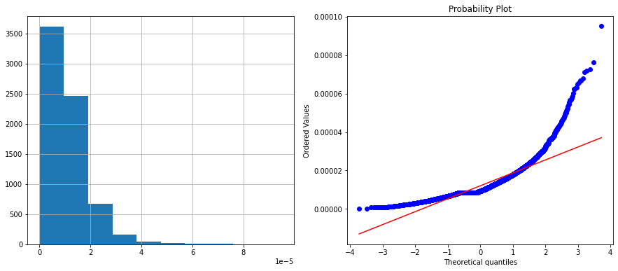

|  | ID | var3 | var15 | imp_ent_var16_ult1 | imp_op_var39_comer_ult1 | imp_op_var39_comer_ult3 | imp_op_var40_comer_ult1 | imp_op_var40_comer_ult3 | imp_op_var40_efect_ult1 | imp_op_var40_efect_ult3 | ... | saldo_medio_var33_hace2 | saldo_medio_var33_hace3 | saldo_medio_var33_ult1 | saldo_medio_var33_ult3 | saldo_medio_var44_hace2 | saldo_medio_var44_hace3 | saldo_medio_var44_ult1 | saldo_medio_var44_ult3 | var38 | var38_reciprocal |
| --- | --- | --- | --- | --- | --- | --- | --- | --- | --- | --- | --- | --- | --- | --- | --- | --- | --- | --- | --- | --- | --- |
| 7681 | 15431 | 2 | 42 | 840.0 | 4477.02 | 4989.54 | 0.0 | 0.0 | 0 | 0 | ... | 0.0 | 0.0 | 0.0 | 0.0 | 0.0 | 0.0 | 0.0 | 0.0 | 37491.21 | 0.000027 |
| 9031 | 18181 | 2 | 31 | 0.0 | 52.32 | 52.32 | 0.0 | 0.0 | 0 | 0 | ... | 0.0 | 0.0 | 0.0 | 0.0 | 0.0 | 0.0 | 0.0 | 0.0 | 106685.94 | 0.000009 |
| 3691 | 7411 | 2 | 51 | 0.0 | 0.00 | 0.00 | 0.0 | 0.0 | 0 | 0 | ... | 0.0 | 0.0 | 0.0 | 0.0 | 0.0 | 0.0 | 0.0 | 0.0 | 66144.66 | 0.000015 |
| 202 | 407 | 2 | 36 | 0.0 | 0.00 | 0.00 | 0.0 | 0.0 | 0 | 0 | ... | 0.0 | 0.0 | 0.0 | 0.0 | 0.0 | 0.0 | 0.0 | 0.0 | 92121.36 | 0.000011 |
| 5625 | 11280 | 2 | 23 | 0.0 | 0.00 | 0.00 | 0.0 | 0.0 | 0 | 0 | ... | 0.0 | 0.0 | 0.0 | 0.0 | 0.0 | 0.0 | 0.0 | 0.0 | 74650.83 | 0.000013 |
| 298 | 598 | 2 | 40 | 0.0 | 0.00 | 0.00 | 0.0 | 0.0 | 0 | 0 | ... | 0.0 | 0.0 | 0.0 | 0.0 | 0.0 | 0.0 | 0.0 | 0.0 | 191698.29 | 0.000005 |

6 rows × 371 columns

```python
def reciprocal_transform(data,cols=[]):
    """
    Reciprocal transformation
    """

    data_copy = data.copy(deep=True)
    for i in cols:
        data_copy[i+'_reciprocal'] = 1/(data_copy[i])
        print('Variable ' + i +' Q-Q plot')
        diagnostic_plots(data_copy,str(i+'_reciprocal'))
    return data_copy

# add the new created feature
X_train_copy = X_train.copy(deep=True)
X_train_copy = X_train_copy[X_train_copy.var38!=0] # Warning that x should not be 0
#X_train_copy[X_train_copy.Fare==0]
X_train_copy = reciprocal_transform(data=X_train_copy,cols=['var38'])
X_train_copy.head(6)
```

#### 3.Square root transformation

```
Variable var38 Q-Q plot
```

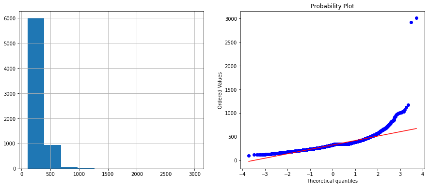

```
         ID  var3  var15  imp_ent_var16_ult1  imp_op_var39_comer_ult1  \
7681  15431     2     42               840.0                  4477.02
9031  18181     2     31                 0.0                    52.32
3691   7411     2     51                 0.0                     0.00
202     407     2     36                 0.0                     0.00
5625  11280     2     23                 0.0                     0.00
298     598     2     40                 0.0                     0.00

      imp_op_var39_comer_ult3  imp_op_var40_comer_ult1  \
7681                  4989.54                      0.0
9031                    52.32                      0.0
3691                     0.00                      0.0
202                      0.00                      0.0
5625                     0.00                      0.0
298                      0.00                      0.0
```

[output cut: 50 more lines]

```python
def square_root_transform(data,cols=[]):
    """
    square root transformation
    """

    data_copy = data.copy(deep=True)
    for i in cols:
        data_copy[i+'_square_root'] = (data_copy[i])**(0.5)
        print('Variable ' + i +' Q-Q plot')
        diagnostic_plots(data_copy,str(i+'_square_root'))
    return data_copy

# add the new created feature
X_train_copy = X_train.copy(deep=True)
X_train_copy = square_root_transform(data=X_train,cols=['var38'])
print(X_train_copy.head(6))
```

#### 4. Exponential transformation

```
Variable var38 Q-Q plot
```

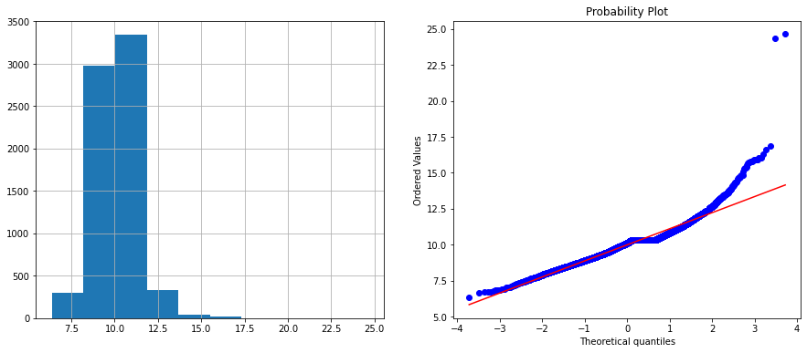

```
         ID  var3  var15  imp_ent_var16_ult1  imp_op_var39_comer_ult1  \
7681  15431     2     42               840.0                  4477.02
9031  18181     2     31                 0.0                    52.32
3691   7411     2     51                 0.0                     0.00
202     407     2     36                 0.0                     0.00
5625  11280     2     23                 0.0                     0.00
298     598     2     40                 0.0                     0.00

      imp_op_var39_comer_ult3  imp_op_var40_comer_ult1  \
7681                  4989.54                      0.0
9031                    52.32                      0.0
3691                     0.00                      0.0
202                      0.00                      0.0
5625                     0.00                      0.0
298                      0.00                      0.0
```

[output cut: 42 more lines]

```python
def exp_transform(data,coef,cols=[]):
    """
    exp transformation
    """

    data_copy = data.copy(deep=True)
    for i in cols:
        data_copy[i+'_exp'] = (data_copy[i])**coef
        print('Variable ' + i +' Q-Q plot')
        diagnostic_plots(data_copy,str(i+'_exp'))
    return data_copy

# add the new created feature
X_train_copy = X_train.copy(deep=True)
X_train_copy = exp_transform(data=X_train,cols=['var38'],coef=0.2)
print(X_train_copy.head(6))
```

```python
from sklearn.preprocessing import PowerTransformer
pt = PowerTransformer().fit(X_train[['var38']])
X_train_copy = X_train.copy(deep=True)
X_train_copy['var38_boxcox'] = pt.transform(X_train_copy[['var38']])
print(X_train_copy.head(6))
```

```
         ID  var3  var15  imp_ent_var16_ult1  imp_op_var39_comer_ult1  \
7681  15431     2     42               840.0                  4477.02
9031  18181     2     31                 0.0                    52.32
3691   7411     2     51                 0.0                     0.00
202     407     2     36                 0.0                     0.00
5625  11280     2     23                 0.0                     0.00
298     598     2     40                 0.0                     0.00

      imp_op_var39_comer_ult3  imp_op_var40_comer_ult1  \
7681                  4989.54                      0.0
9031                    52.32                      0.0
3691                     0.00                      0.0
202                      0.00                      0.0
5625                     0.00                      0.0
298                      0.00                      0.0
```

[output cut: 42 more lines]

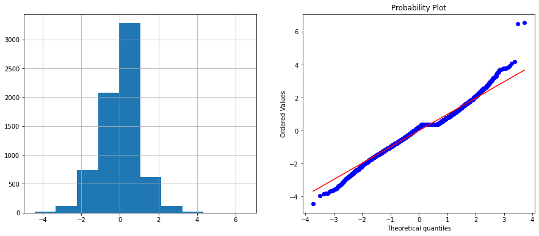

```python
diagnostic_plots(X_train_copy,'var38_boxcox')
```

#### 6. Quantile transformation

```python
from sklearn.preprocessing import QuantileTransformer
qt = QuantileTransformer(output_distribution='normal').fit(X_train[['var38']])
X_train_copy = X_train.copy(deep=True)
X_train_copy['var38_quantile'] = qt.transform(X_train_copy[['var38']])
print(X_train_copy.head(6))
```

```
         ID  var3  var15  imp_ent_var16_ult1  imp_op_var39_comer_ult1  \
7681  15431     2     42               840.0                  4477.02
9031  18181     2     31                 0.0                    52.32
3691   7411     2     51                 0.0                     0.00
202     407     2     36                 0.0                     0.00
5625  11280     2     23                 0.0                     0.00
298     598     2     40                 0.0                     0.00

      imp_op_var39_comer_ult3  imp_op_var40_comer_ult1  \
7681                  4989.54                      0.0
9031                    52.32                      0.0
3691                     0.00                      0.0
202                      0.00                      0.0
5625                     0.00                      0.0
298                      0.00                      0.0
```

[output cut: 50 more lines]

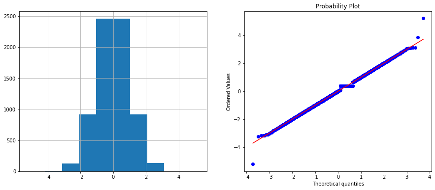

```python
diagnostic_plots(X_train_copy,'var38_quantile')
```

### 4. Normalisasi

[figure not shown]

# 4. RESAMPLING

```python
df=pd.read_csv('WA_Fn-UseC_-Telco-Customer-Churn.csv', na_values=[' '])
df["TotalCharges"] = pd.to_numeric(df["TotalCharges"],errors="coerce")
df.dropna(how="any",inplace=True)
```

```python
yes_no_columns = ['Partner','SeniorCitizen', 'Dependents','PhoneService','PaperlessBilling','Churn']
for col in yes_no_columns:
    df[col].replace({'Yes': 1,'No': 0},inplace=True)
```

```python
cols2=['gender','InternetService','Contract','PaymentMethod', 'MultipleLines',
      'StreamingMovies', 'OnlineSecurity', 'OnlineBackup',
      'DeviceProtection', 'TechSupport', 'StreamingTV']
df = pd.get_dummies(data=df, columns=cols2)
```

```python
df = df.drop(columns='customerID')
```

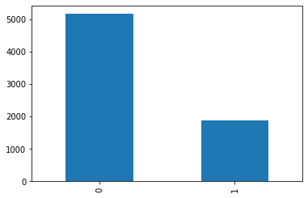

```python
df['Churn'].value_counts().plot(kind='bar')
```

```python
X = df[cols]
y = df['Churn']
```

```python
X_train, X_test, y_train, y_test = train_test_split(X, y, test_size=0.1, random_state=42, stratify=y)
X_train, X_val, y_train, y_val = train_test_split(X_train, y_train, test_size=2/9, random_state=42, stratify=y_train)
X_train.shape, X_val.shape, X_test.shape
```

```
((4921, 29), (1407, 29), (704, 29))
```

```python
X_train
```

|  | SeniorCitizen | Partner | Dependents | tenure | PaperlessBilling | MonthlyCharges | TotalCharges | InternetService_DSL | InternetService_Fiber optic | InternetService_No | ... | OnlineSecurity_Yes | OnlineBackup_No | OnlineBackup_No internet service | DeviceProtection_No | DeviceProtection_No internet service | TechSupport_No | TechSupport_No internet service | TechSupport_Yes | StreamingTV_No | StreamingTV_No internet service |
| --- | --- | --- | --- | --- | --- | --- | --- | --- | --- | --- | --- | --- | --- | --- | --- | --- | --- | --- | --- | --- | --- |
| 2402 | 0 | 0 | 1 | 6 | 0 | 19.70 | 111.65 | 0 | 0 | 1 | ... | 0 | 0 | 1 | 0 | 1 | 0 | 1 | 0 | 0 | 1 |
| 3747 | 0 | 1 | 1 | 4 | 1 | 58.50 | 224.85 | 1 | 0 | 0 | ... | 0 | 0 | 0 | 1 | 0 | 0 | 0 | 1 | 1 | 0 |
| 742 | 0 | 0 | 0 | 10 | 0 | 98.55 | 1008.55 | 0 | 1 | 0 | ... | 1 | 1 | 0 | 1 | 0 | 1 | 0 | 0 | 0 | 0 |
| 3298 | 0 | 0 | 0 | 4 | 0 | 20.05 | 83.30 | 0 | 0 | 1 | ... | 0 | 0 | 1 | 0 | 1 | 0 | 1 | 0 | 0 | 1 |
| 3866 | 0 | 1 | 1 | 19 | 0 | 25.60 | 485.90 | 0 | 0 | 1 | ... | 0 | 0 | 1 | 0 | 1 | 0 | 1 | 0 | 0 | 1 |
| ... | ... | ... | ... | ... | ... | ... | ... | ... | ... | ... | ... | ... | ... | ... | ... | ... | ... | ... | ... | ... | ... |
| 3190 | 0 | 1 | 1 | 66 | 0 | 54.65 | 3632.00 | 1 | 0 | 0 | ... | 0 | 1 | 0 | 0 | 0 | 0 | 0 | 1 | 0 | 0 |
| 3441 | 0 | 1 | 1 | 34 | 1 | 60.80 | 2042.05 | 1 | 0 | 0 | ... | 1 | 0 | 0 | 0 | 0 | 1 | 0 | 0 | 1 | 0 |
| 4622 | 0 | 0 | 0 | 52 | 1 | 83.80 | 4331.40 | 0 | 1 | 0 | ... | 0 | 1 | 0 | 0 | 0 | 1 | 0 | 0 | 1 | 0 |
| 1229 | 0 | 1 | 0 | 61 | 0 | 75.35 | 4729.30 | 1 | 0 | 0 | ... | 1 | 1 | 0 | 0 | 0 | 0 | 0 | 1 | 1 | 0 |
| 3881 | 0 | 1 | 0 | 71 | 0 | 65.15 | 4681.75 | 1 | 0 | 0 | ... | 1 | 0 | 0 | 1 | 0 | 0 | 0 | 1 | 1 | 0 |

4921 rows × 29 columns

# OVERSAMPLING

```python
from imblearn.over_sampling import SMOTE
oversample = SMOTE(sampling_strategy='minority')
X_train, y_train = oversample.fit_resample(X_train, y_train)
```

```python
baru = pd.concat([X_train, y_train], axis=1)
```

```python
baru
```

|  | SeniorCitizen | Partner | Dependents | tenure | PaperlessBilling | MonthlyCharges | TotalCharges | InternetService_DSL | InternetService_Fiber optic | InternetService_No | ... | OnlineBackup_No | OnlineBackup_No internet service | DeviceProtection_No | DeviceProtection_No internet service | TechSupport_No | TechSupport_No internet service | TechSupport_Yes | StreamingTV_No | StreamingTV_No internet service | Churn |
| --- | --- | --- | --- | --- | --- | --- | --- | --- | --- | --- | --- | --- | --- | --- | --- | --- | --- | --- | --- | --- | --- |
| 0 | 0 | 0 | 1 | 6 | 0 | 19.700000 | 111.650000 | 0 | 0 | 1 | ... | 0 | 1 | 0 | 1 | 0 | 1 | 0 | 0 | 1 | 0 |
| 1 | 0 | 1 | 1 | 4 | 1 | 58.500000 | 224.850000 | 1 | 0 | 0 | ... | 0 | 0 | 1 | 0 | 0 | 0 | 1 | 1 | 0 | 0 |
| 2 | 0 | 0 | 0 | 10 | 0 | 98.550000 | 1008.550000 | 0 | 1 | 0 | ... | 1 | 0 | 1 | 0 | 1 | 0 | 0 | 0 | 0 | 1 |
| 3 | 0 | 0 | 0 | 4 | 0 | 20.050000 | 83.300000 | 0 | 0 | 1 | ... | 0 | 1 | 0 | 1 | 0 | 1 | 0 | 0 | 1 | 0 |
| 4 | 0 | 1 | 1 | 19 | 0 | 25.600000 | 485.900000 | 0 | 0 | 1 | ... | 0 | 1 | 0 | 1 | 0 | 1 | 0 | 0 | 1 | 0 |
| ... | ... | ... | ... | ... | ... | ... | ... | ... | ... | ... | ... | ... | ... | ... | ... | ... | ... | ... | ... | ... | ... |
| 7221 | 0 | 0 | 0 | 26 | 1 | 89.616358 | 2385.956974 | 0 | 1 | 0 | ... | 0 | 0 | 1 | 0 | 1 | 0 | 0 | 0 | 0 | 1 |
| 7222 | 0 | 0 | 0 | 2 | 1 | 79.606600 | 152.733454 | 0 | 1 | 0 | ... | 1 | 0 | 1 | 0 | 1 | 0 | 0 | 0 | 0 | 1 |
| 7223 | 0 | 0 | 0 | 1 | 1 | 69.596903 | 69.596903 | 0 | 1 | 0 | ... | 1 | 0 | 1 | 0 | 1 | 0 | 0 | 1 | 0 | 1 |
| 7224 | 0 | 0 | 0 | 63 | 1 | 100.092526 | 6266.575175 | 0 | 1 | 0 | ... | 0 | 0 | 0 | 0 | 1 | 0 | 0 | 0 | 0 | 1 |
| 7225 | 0 | 0 | 0 | 30 | 1 | 79.460942 | 2395.959297 | 0 | 1 | 0 | ... | 1 | 0 | 1 | 0 | 0 | 0 | 0 | 0 | 0 | 1 |

7226 rows × 30 columns

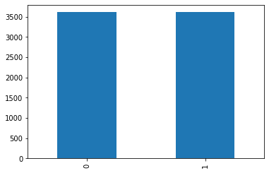

```python
baru['Churn'].value_counts().plot(kind='bar')
```

# UNDERSAMPLING

```python
X = df[cols]
y = df['Churn']
```

```python
X_train, X_test, y_train, y_test = train_test_split(X, y, test_size=0.1, random_state=42, stratify=y)
X_train, X_val, y_train, y_val = train_test_split(X_train, y_train, test_size=2/9, random_state=42, stratify=y_train)
X_train.shape, X_val.shape, X_test.shape
```

```
((4921, 29), (1407, 29), (704, 29))
```

```python
X_train
```

|  | SeniorCitizen | Partner | Dependents | tenure | PaperlessBilling | MonthlyCharges | TotalCharges | InternetService_DSL | InternetService_Fiber optic | InternetService_No | ... | OnlineSecurity_Yes | OnlineBackup_No | OnlineBackup_No internet service | DeviceProtection_No | DeviceProtection_No internet service | TechSupport_No | TechSupport_No internet service | TechSupport_Yes | StreamingTV_No | StreamingTV_No internet service |
| --- | --- | --- | --- | --- | --- | --- | --- | --- | --- | --- | --- | --- | --- | --- | --- | --- | --- | --- | --- | --- | --- |
| 2402 | 0 | 0 | 1 | 6 | 0 | 19.70 | 111.65 | 0 | 0 | 1 | ... | 0 | 0 | 1 | 0 | 1 | 0 | 1 | 0 | 0 | 1 |
| 3747 | 0 | 1 | 1 | 4 | 1 | 58.50 | 224.85 | 1 | 0 | 0 | ... | 0 | 0 | 0 | 1 | 0 | 0 | 0 | 1 | 1 | 0 |
| 742 | 0 | 0 | 0 | 10 | 0 | 98.55 | 1008.55 | 0 | 1 | 0 | ... | 1 | 1 | 0 | 1 | 0 | 1 | 0 | 0 | 0 | 0 |
| 3298 | 0 | 0 | 0 | 4 | 0 | 20.05 | 83.30 | 0 | 0 | 1 | ... | 0 | 0 | 1 | 0 | 1 | 0 | 1 | 0 | 0 | 1 |
| 3866 | 0 | 1 | 1 | 19 | 0 | 25.60 | 485.90 | 0 | 0 | 1 | ... | 0 | 0 | 1 | 0 | 1 | 0 | 1 | 0 | 0 | 1 |
| ... | ... | ... | ... | ... | ... | ... | ... | ... | ... | ... | ... | ... | ... | ... | ... | ... | ... | ... | ... | ... | ... |
| 3190 | 0 | 1 | 1 | 66 | 0 | 54.65 | 3632.00 | 1 | 0 | 0 | ... | 0 | 1 | 0 | 0 | 0 | 0 | 0 | 1 | 0 | 0 |
| 3441 | 0 | 1 | 1 | 34 | 1 | 60.80 | 2042.05 | 1 | 0 | 0 | ... | 1 | 0 | 0 | 0 | 0 | 1 | 0 | 0 | 1 | 0 |
| 4622 | 0 | 0 | 0 | 52 | 1 | 83.80 | 4331.40 | 0 | 1 | 0 | ... | 0 | 1 | 0 | 0 | 0 | 1 | 0 | 0 | 1 | 0 |
| 1229 | 0 | 1 | 0 | 61 | 0 | 75.35 | 4729.30 | 1 | 0 | 0 | ... | 1 | 1 | 0 | 0 | 0 | 0 | 0 | 1 | 1 | 0 |
| 3881 | 0 | 1 | 0 | 71 | 0 | 65.15 | 4681.75 | 1 | 0 | 0 | ... | 1 | 0 | 0 | 1 | 0 | 0 | 0 | 1 | 1 | 0 |

4921 rows × 29 columns

```python
undersamp = pd.concat([X_train, y_train], axis=1)
undersamp
```

|  | SeniorCitizen | Partner | Dependents | tenure | PaperlessBilling | MonthlyCharges | TotalCharges | InternetService_DSL | InternetService_Fiber optic | InternetService_No | ... | OnlineBackup_No | OnlineBackup_No internet service | DeviceProtection_No | DeviceProtection_No internet service | TechSupport_No | TechSupport_No internet service | TechSupport_Yes | StreamingTV_No | StreamingTV_No internet service | Churn |
| --- | --- | --- | --- | --- | --- | --- | --- | --- | --- | --- | --- | --- | --- | --- | --- | --- | --- | --- | --- | --- | --- |
| 2402 | 0 | 0 | 1 | 6 | 0 | 19.70 | 111.65 | 0 | 0 | 1 | ... | 0 | 1 | 0 | 1 | 0 | 1 | 0 | 0 | 1 | 0 |
| 3747 | 0 | 1 | 1 | 4 | 1 | 58.50 | 224.85 | 1 | 0 | 0 | ... | 0 | 0 | 1 | 0 | 0 | 0 | 1 | 1 | 0 | 0 |
| 742 | 0 | 0 | 0 | 10 | 0 | 98.55 | 1008.55 | 0 | 1 | 0 | ... | 1 | 0 | 1 | 0 | 1 | 0 | 0 | 0 | 0 | 1 |
| 3298 | 0 | 0 | 0 | 4 | 0 | 20.05 | 83.30 | 0 | 0 | 1 | ... | 0 | 1 | 0 | 1 | 0 | 1 | 0 | 0 | 1 | 0 |
| 3866 | 0 | 1 | 1 | 19 | 0 | 25.60 | 485.90 | 0 | 0 | 1 | ... | 0 | 1 | 0 | 1 | 0 | 1 | 0 | 0 | 1 | 0 |
| ... | ... | ... | ... | ... | ... | ... | ... | ... | ... | ... | ... | ... | ... | ... | ... | ... | ... | ... | ... | ... | ... |
| 3190 | 0 | 1 | 1 | 66 | 0 | 54.65 | 3632.00 | 1 | 0 | 0 | ... | 1 | 0 | 0 | 0 | 0 | 0 | 1 | 0 | 0 | 0 |
| 3441 | 0 | 1 | 1 | 34 | 1 | 60.80 | 2042.05 | 1 | 0 | 0 | ... | 0 | 0 | 0 | 0 | 1 | 0 | 0 | 1 | 0 | 0 |
| 4622 | 0 | 0 | 0 | 52 | 1 | 83.80 | 4331.40 | 0 | 1 | 0 | ... | 1 | 0 | 0 | 0 | 1 | 0 | 0 | 1 | 0 | 0 |
| 1229 | 0 | 1 | 0 | 61 | 0 | 75.35 | 4729.30 | 1 | 0 | 0 | ... | 1 | 0 | 0 | 0 | 0 | 0 | 1 | 1 | 0 | 0 |
| 3881 | 0 | 1 | 0 | 71 | 0 | 65.15 | 4681.75 | 1 | 0 | 0 | ... | 0 | 0 | 1 | 0 | 0 | 0 | 1 | 1 | 0 | 0 |

4921 rows × 30 columns

```python
deposit0 = undersamp[undersamp['Churn'] == 0]
deposit1 = undersamp[undersamp['Churn'] == 1]
new_data = pd.concat([deposit0.sample(len(deposit1), random_state =0), deposit1], axis =0).reset_index(drop=True)
new_data
```

|  | SeniorCitizen | Partner | Dependents | tenure | PaperlessBilling | MonthlyCharges | TotalCharges | InternetService_DSL | InternetService_Fiber optic | InternetService_No | ... | OnlineBackup_No | OnlineBackup_No internet service | DeviceProtection_No | DeviceProtection_No internet service | TechSupport_No | TechSupport_No internet service | TechSupport_Yes | StreamingTV_No | StreamingTV_No internet service | Churn |
| --- | --- | --- | --- | --- | --- | --- | --- | --- | --- | --- | --- | --- | --- | --- | --- | --- | --- | --- | --- | --- | --- |
| 0 | 0 | 0 | 0 | 13 | 0 | 55.15 | 742.90 | 1 | 0 | 0 | ... | 1 | 0 | 1 | 0 | 0 | 0 | 1 | 1 | 0 | 0 |
| 1 | 0 | 0 | 0 | 12 | 0 | 20.15 | 260.70 | 0 | 0 | 1 | ... | 0 | 1 | 0 | 1 | 0 | 1 | 0 | 0 | 1 | 0 |
| 2 | 0 | 1 | 0 | 63 | 0 | 79.80 | 5034.05 | 1 | 0 | 0 | ... | 1 | 0 | 0 | 0 | 0 | 0 | 1 | 0 | 0 | 0 |
| 3 | 0 | 0 | 0 | 23 | 0 | 83.20 | 2032.30 | 0 | 1 | 0 | ... | 0 | 0 | 0 | 0 | 0 | 0 | 1 | 1 | 0 | 0 |
| 4 | 0 | 1 | 1 | 62 | 1 | 24.25 | 1424.60 | 0 | 0 | 1 | ... | 0 | 1 | 0 | 1 | 0 | 1 | 0 | 0 | 1 | 0 |
| ... | ... | ... | ... | ... | ... | ... | ... | ... | ... | ... | ... | ... | ... | ... | ... | ... | ... | ... | ... | ... | ... |
| 2611 | 0 | 0 | 0 | 5 | 0 | 54.20 | 308.25 | 1 | 0 | 0 | ... | 1 | 0 | 1 | 0 | 0 | 0 | 1 | 1 | 0 | 1 |
| 2612 | 1 | 0 | 0 | 18 | 1 | 85.45 | 1505.85 | 0 | 1 | 0 | ... | 0 | 0 | 1 | 0 | 0 | 0 | 1 | 1 | 0 | 1 |
| 2613 | 1 | 1 | 0 | 58 | 1 | 45.30 | 2651.20 | 1 | 0 | 0 | ... | 0 | 0 | 0 | 0 | 1 | 0 | 0 | 1 | 0 | 1 |
| 2614 | 0 | 1 | 1 | 4 | 1 | 85.95 | 381.30 | 0 | 1 | 0 | ... | 1 | 0 | 1 | 0 | 1 | 0 | 0 | 1 | 0 | 1 |
| 2615 | 0 | 0 | 0 | 3 | 0 | 25.25 | 58.90 | 1 | 0 | 0 | ... | 1 | 0 | 1 | 0 | 1 | 0 | 0 | 1 | 0 | 1 |

2616 rows × 30 columns

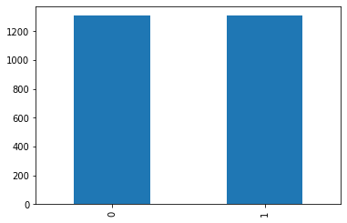

```python
new_data['Churn'].value_counts().plot(kind='bar')
```

```python
X_train = new_data.drop(labels='Churn', axis = 1)
y_train = new_data['Churn']
```